| title: “DIppolito_Final Project” |
| --- |
| author: “Michelle D’Ippolito” |
| date: “Wednesday, January 21, 2015” |
| output: html_document |

1. Get the distribution of relationships from T3-T7 and plot them on histograms

```r
#read in data
library(reshape2)
library(ggplot2)

mySP <- read.csv("SPTimePeriods.csv")
head(mySP)
```

```
##         ID   Relationship T0 T1 T2 T3 T4 T5 T6 T7 T8 T9 T10 T11 T12
## 1 Alan_Tam    Dan_Xin_Lin  0  2  2  2  2  2  2  0  0  0   0   0   0
## 2 Alan_Tam            FBI  0  0  0  0  0  0 10  0  0  0   0   0   0
## 3 Alan_Tam   Guo_Liang_Qi  0  2  2  2  2  2  2  0  0  0   0   0   0
## 4 Alan_Tam   Guo_Liang_Qi  0 13 13 13 13 13 13 13 13 13   0   0   0
## 5 Alan_Tam  Guo Liang Qun  0  2  2  2  2  2  2  0  0  0   0   0   0
## 6 Alan_Tam Guo_Liang_Wang  0  2  2  2  2  2  2  0  0  0   0   0   0
```

```r
#add RelID column

mySP$RelID <- 1:nrow(mySP)
mySP$RelID <- paste("Rel", 1:nrow(mySP), sep = "")
head(mySP)
```

```
##         ID   Relationship T0 T1 T2 T3 T4 T5 T6 T7 T8 T9 T10 T11 T12 RelID
## 1 Alan_Tam    Dan_Xin_Lin  0  2  2  2  2  2  2  0  0  0   0   0   0  Rel1
## 2 Alan_Tam            FBI  0  0  0  0  0  0 10  0  0  0   0   0   0  Rel2
## 3 Alan_Tam   Guo_Liang_Qi  0  2  2  2  2  2  2  0  0  0   0   0   0  Rel3
## 4 Alan_Tam   Guo_Liang_Qi  0 13 13 13 13 13 13 13 13 13   0   0   0  Rel4
## 5 Alan_Tam  Guo Liang Qun  0  2  2  2  2  2  2  0  0  0   0   0   0  Rel5
## 6 Alan_Tam Guo_Liang_Wang  0  2  2  2  2  2  2  0  0  0   0   0   0  Rel6
```

```r
#create dataframe of just the timeperiods want
mySP2 <- mySP[, c("ID","Relationship", "T3", "T4", "T5", "T6", "T7", "RelID")]
head(mySP2)
```

```
##         ID   Relationship T3 T4 T5 T6 T7 RelID
## 1 Alan_Tam    Dan_Xin_Lin  2  2  2  2  0  Rel1
## 2 Alan_Tam            FBI  0  0  0 10  0  Rel2
## 3 Alan_Tam   Guo_Liang_Qi  2  2  2  2  0  Rel3
## 4 Alan_Tam   Guo_Liang_Qi 13 13 13 13 13  Rel4
## 5 Alan_Tam  Guo Liang Qun  2  2  2  2  0  Rel5
## 6 Alan_Tam Guo_Liang_Wang  2  2  2  2  0  Rel6
```

```r
#melt mydf to get the correct variables
mySP2.melt <- melt(mySP2, id.vars = c("RelID", "ID", "Relationship"), value.name = "relationship.type", variable.name = "time.period")
summary(mySP2.melt)
```

```
##     RelID                         ID               Relationship
##  Length:1460        Cheng_Chui_Ping:140   Guo_Liang_Qi   :170
##  Class :character   Guo_Liang_Qi   :140   Cheng_Chui_Ping:125
##  Mode  :character   Dan_Xin_Lin    : 75   Guo Liang Qun  : 55
##                     Chao_Lin_Feng  : 65   Guo_Liang_Wang : 55
##                     Cho_Lee_Lin    : 65   Dan_Xin_Lin    : 50
##                     Jeffrey_Zhu    : 65   Cheng_Yik_Tak  : 45
##                     (Other)        :910   (Other)        :960
##  time.period relationship.type
##  T3:292      Min.   : 0.000
##  T4:292      1st Qu.: 0.000
##  T5:292      Median : 2.000
##  T6:292      Mean   : 1.871
##  T7:292      3rd Qu.: 2.000
##              Max.   :13.000
##
```

```r
head(mySP2.melt)
```

```
##   RelID       ID   Relationship time.period relationship.type
## 1  Rel1 Alan_Tam    Dan_Xin_Lin          T3                 2
## 2  Rel2 Alan_Tam            FBI          T3                 0
## 3  Rel3 Alan_Tam   Guo_Liang_Qi          T3                 2
## 4  Rel4 Alan_Tam   Guo_Liang_Qi          T3                13
## 5  Rel5 Alan_Tam  Guo Liang Qun          T3                 2
## 6  Rel6 Alan_Tam Guo_Liang_Wang          T3                 2
```

```r
#recast the data to find the distributions
mySP2.cast <- dcast(mySP2.melt, time.period ~ relationship.type)
mySP2.cast
```

```
##   time.period   0 1   2  3 4 6 7  8 9 10 13
## 1          T3 118 2 113 39 2 7 1  1 2  1  6
## 2          T4 126 2  99 39 0 7 8  1 3  1  6
## 3          T5 126 2  98 39 0 7 8  1 3  2  6
## 4          T6  87 2  97 39 0 8 8 38 4  3  6
## 5          T7 237 0   8 29 0 7 1  0 3  1  6
```

```r
mySP2.cast2 <- dcast(mySP2.melt, relationship.type ~ time.period)
mySP2.cast2
```

```
##    relationship.type  T3  T4  T5 T6  T7
## 1                  0 118 126 126 87 237
## 2                  1   2   2   2  2   0
## 3                  2 113  99  98 97   8
## 4                  3  39  39  39 39  29
## 5                  4   2   0   0  0   0
## 6                  6   7   7   7  8   7
## 7                  7   1   8   8  8   1
## 8                  8   1   1   1 38   0
## 9                  9   2   3   3  4   3
## 10                10   1   1   2  3   1
## 11                13   6   6   6  6   6
```

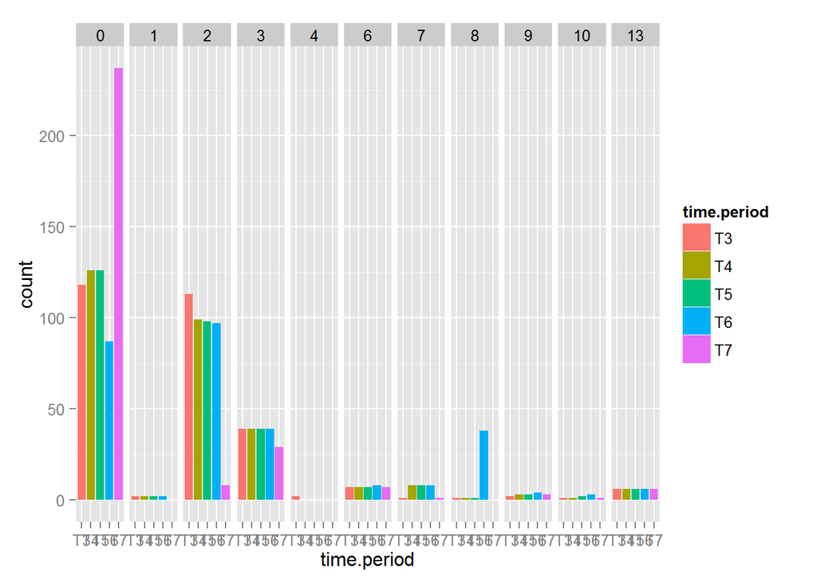

```r
#plot a histogram
mybaseplot <- ggplot(mySP2.melt, aes(x = time.period))
mybaseplot + geom_histogram(aes(fill = time.period)) + facet_grid(. ~ relationship.type)
```

2. Create a network diagram of one time period across all the relationship types.

My original dataset had too many layers of information happening at once in order for the program to parse it correctly. As a result, I had to create a separate datafile for each of the time periods in question and remove the attributes of what kind of relationship the edge represents. This required manipulating the data outside of r to create a new file because it needed to be in a different fundamental format that I could not get to replicate in R.

```r
library(igraph)

#creating a graph object for T3-T7 in igraph.

T3.csv <- read.csv("T3EdgeList.csv")
T3.g <- graph.data.frame(T3.csv, directed = TRUE)
T3.g
```

```
## IGRAPH DN-- 40 174 --
## + attr: name (v/c)
```

```r
T4.csv <- read.csv("T4EdgeList.csv")
T4.g <- graph.data.frame(T4.csv, directed = TRUE)
T4.g
```

```
## IGRAPH DN-- 41 166 --
## + attr: name (v/c)
```

```r
T5.csv <- read.csv("T5EdgeList.csv")
T5.g <- graph.data.frame(T5.csv, directed = TRUE)
T5.g
```

```
## IGRAPH DN-- 41 166 --
## + attr: name (v/c)
```

```r
T6.csv <- read.csv("T6EdgeList.csv")
T6.g <- graph.data.frame(T6.csv, directed = TRUE)
T6.g
```

```
## IGRAPH DN-- 45 205 --
## + attr: name (v/c)
```

```r
T7.csv <- read.csv("T7EdgeList.csv")
T7.g <- graph.data.frame(T7.csv, directed = TRUE)
T7.g
```

```
## IGRAPH DN-- 22 55 --
## + attr: name (v/c)
```

[figure not shown]

```r
#plotting the T3-T7 network diagrams

T3 <- plot.igraph(T3.g, vertex.size = 3.5, edge.arrow.size = 0.4, vertex.label.dist = 0.3, vertex.label.degree = pi/2, vertex.label.cex = 0.75, main = "Time Period 3 July - December 1992", margin = -0.1, asp = -1)
```

[figure not shown]

```r
T4 <- plot.igraph(T4.g, vertex.size = 3.5, edge.arrow.size = 0.4, vertex.label.dist = 0.3, vertex.label.degree = pi/2, vertex.label.cex = 0.75, main = "Time Period 4 January - February 1993", margin = -0.1, asp = -1)
```

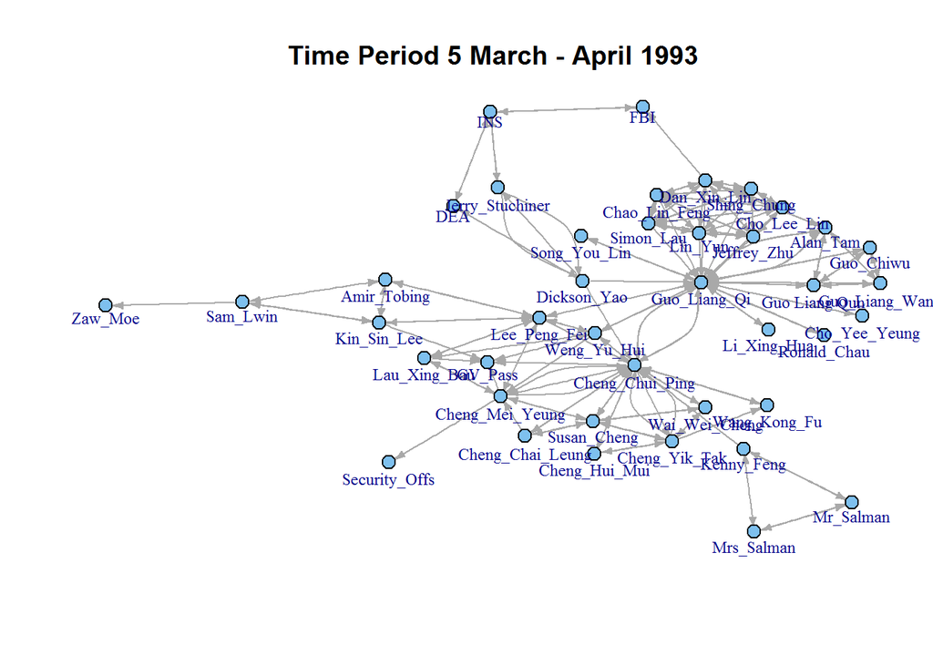

```r
T5 <- plot.igraph(T5.g, vertex.size = 3.5, edge.arrow.size = 0.4, vertex.label.dist = 0.3, vertex.label.degree = pi/2, vertex.label.cex = 0.75, main = "Time Period 5 March - April 1993", margin = -0.1, asp = -1)
```

[figure not shown]

```r
T6 <- plot.igraph(T6.g, vertex.size = 3.5, edge.arrow.size = 0.4, vertex.label.dist = 0.3, vertex.label.degree = pi/2, vertex.label.cex = 0.75, main = "Time Period 6 May - June 1993", margin = -0.1, asp = -1)
```

[figure not shown]

```r
T7 <- plot.igraph(T7.g, vertex.size = 3.5, edge.arrow.size = 0.4, vertex.label.dist = 0.3, vertex.label.degree = pi/2, vertex.label.cex = 0.75, main = "Time Period 7 July - August 1993", margin = -0.1, asp = -1)
```

```r
T3.cd <- centralization.degree(T3.g)
T4.cd <- centralization.degree(T4.g)
T5.cd <- centralization.degree(T5.g)
T6.cd <- centralization.degree(T6.g)
T7.cd <- centralization.degree(T7.g)
```